# Third places - Preliminary analysis

Alexandre Naud

July 14th, 2021

These analysis follow the work of Firth CL and al., (2020) presented at the *American Public Health Association Annual Meeting and Expo* (October 2020).

See this [presentation](https://www.slideshare.net/teaminteract/third-places-and-their-role-for-population-health-a-study-in-montreal-canada)

# A. InterAct - Montreal

- Cross-sectionnal observationnal studies
- 1155 participant aged from 18 to 85 years old and living in the Montreal area
- 833 have completed the VERITAS social questionnaire

# B. Data preparation

## Cleaning other locations

- In this study, participant could identify locations as `others`
- They represent 641 of the 18184 reported locations (3.5%)
- Most of these locations could be reclassified accordings to the verbatime description
- I created 5 new categories: `Community organization`, `Daycare`, `Library`, `Shopping center` and `Store`
- 563 (88%) were reclassified, 364 (65%) were in new categories

## What we define as third places

- Categories defined by Firth CL and al.:
  - **Park**
  - **Restaurant, bar and café**
  - **sports**
  - **Cultural and non-physical leisure activity**
  - **Religious or spiritual**
  - **Volunteering**
- I added the following:
  - **Community organization**
  - **Shopping center**

## Calculating the number of people seen third places

### Transforming group data

- How many people are in groups?
- If we use group size, we bias the number of people towards large value
  - E.g. Some groups have size > 100
- Weight by the square root of group size

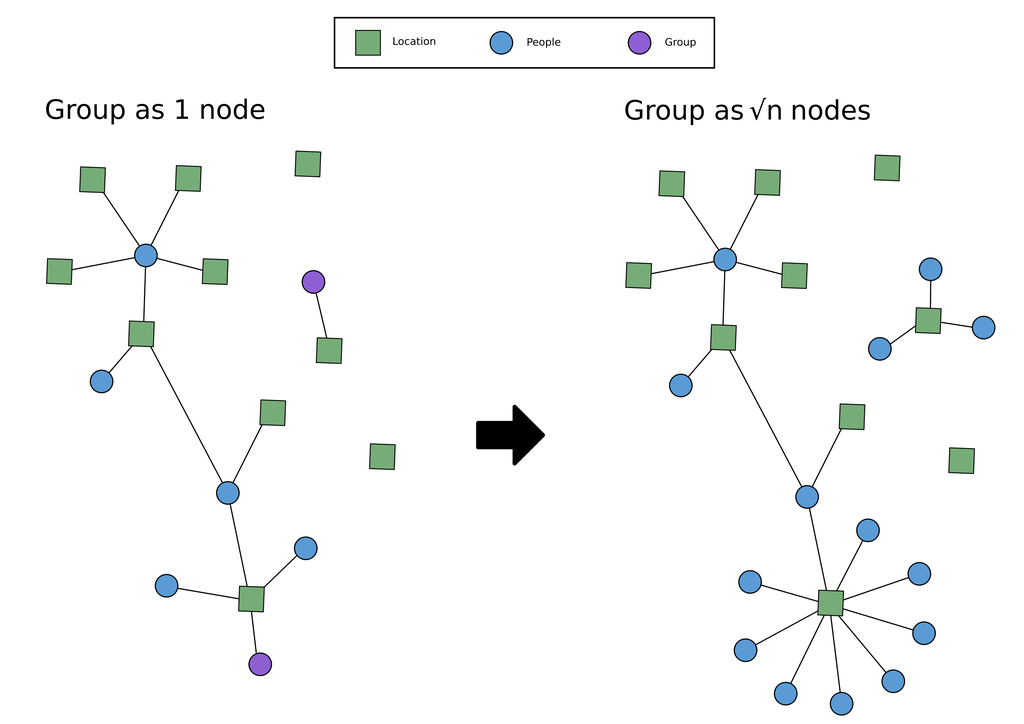

**Transforming group in $\sqrt{n}$ where $n = group_size$**

### Counting people by third places

- A participant can have several third places
- Similar people can be comonly seen accross third places

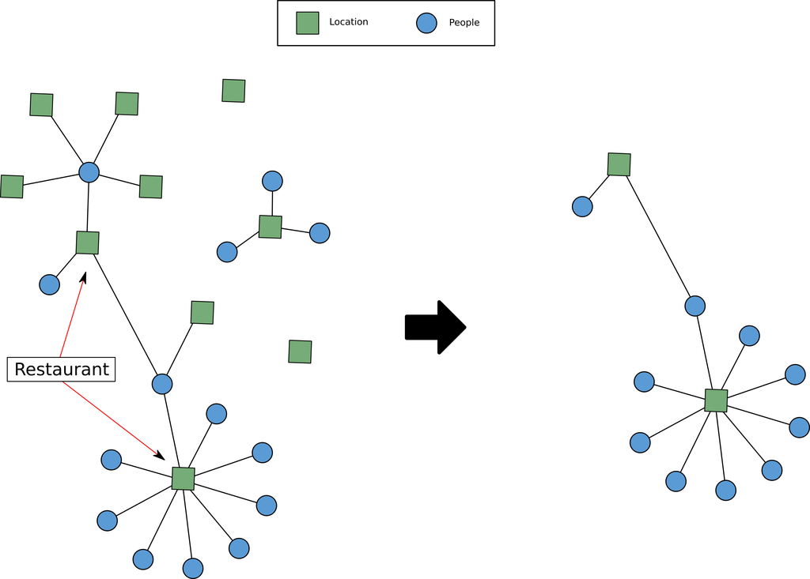

# C. Variables description

Description of the variables used in the following analysis

## Socio-demographic

| Code | Description | Type | Raw or Generated |
| --- | --- | --- | --- |
| age | Number of years lived | continuous | raw |
| age_group | Which age categories | categorial | generated |
| gender | Current gender identity | categorial | raw |
| group_white | White or non-white | categorial | generated |
| income | Annual household income | categorial | raw |

## Well-being

| Description | Code | Type | Raw or Generated |
| --- | --- | --- | --- |
| pwb | Personnal well-being index | continuous | raw |

## Visited third places

| Description | Code | Type | Raw or Generated |
| --- | --- | --- | --- |
| park | Number of visited parks | ordinal | generated |
| sport | … visited sport facility | ordinal | generated |
| cultural | … cultural and leisure | ordinal | generated |
| volunteering | … volontering activities | ordinal | generated |
| religious | … religious and spiritual | ordinal | generated |
| restaurant | … restaurant, bar and café | ordinal | generated |
| third | … all third places | ordinal | generated |

## People seen in third places

| Description | Code | Type | Raw or Generated |
| --- | --- | --- | --- |
| people_important | Number of important people seen in third places | ordinal | generated |
| people_socialize | … people with whom one like to socialize… | ordinal | generated |
| people_individuals | … individualy reported people… | ordinal | generated |
| people_all | … people (including those from groups)… | ordinal | generated |

*These variables were also stratified by third places type* *(e.g. number of important people seen in park)*

# D. Univariate

Distributions of all variables.

## Age (continuous) and well-being

| variable | min | Q1 | median | mean | Q3 | max |
| --- | --- | --- | --- | --- | --- | --- |
| age | 18 | 32.0 | 43.0 | 45.01 | 58.0 | 85 |
| pwb | 0 | 6.9 | 7.7 | 7.45 | 8.4 | 10 |

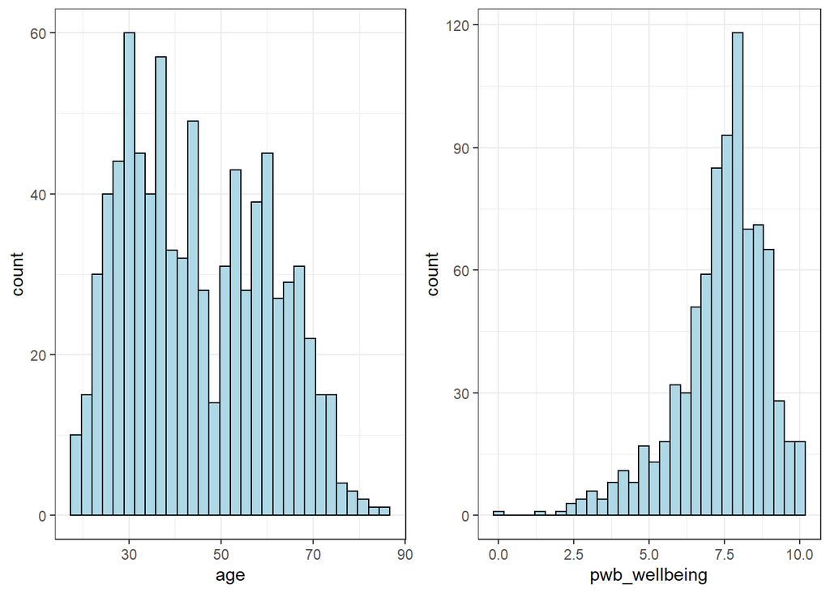

## Age (categorial) gender, income and being white

| variable | count | prop |
| --- | --- | --- |
| **Age group** |  |  |
| 18-24 | 55 | 0.07 |
| 25-34 | 207 | 0.25 |
| 35-44 | 176 | 0.21 |
| 45-54 | 133 | 0.16 |
| 55-64 | 156 | 0.19 |
| 65+ | 106 | 0.13 |
| **Gender** |  |  |
| woman | 562 | 0.67 |
| man | 264 | 0.32 |
| other | 7 | 0.01 |
| **Income** |  |  |
| no income | 4 | 0.01 |
| 1 to 9.999 | 8 | 0.01 |
| 10,000 to 14,999 | 23 | 0.03 |
| 15,000 to 19,999 | 17 | 0.02 |
| 20,000 to 29,999 | 44 | 0.06 |
| 30,000 to 39,999 | 34 | 0.04 |
| 40,000 to 49,999 | 67 | 0.09 |
| 50,000 to 99,999 | 283 | 0.37 |
| 100,000 to 149,999 | 158 | 0.21 |
| 150,000 to 199,999 | 78 | 0.10 |
| 200,000 or more | 52 | 0.07 |
| **White** |  |  |
| FALSE | 108 | 0.13 |
| TRUE | 725 | 0.87 |

## Number of third places

| Variable | Nb_0 | Prop_0 | Min | Median | Mean | Q3 | Max |
| --- | --- | --- | --- | --- | --- | --- | --- |
| sport | 258 | 0.31 | 1 | 1 | 1.71 | 2 | 6 |
| park | 306 | 0.37 | 1 | 1 | 1.98 | 3 | 5 |
| cultural | 506 | 0.61 | 1 | 2 | 2.28 | 3 | 9 |
| volunteering | 649 | 0.78 | 1 | 1 | 1.42 | 2 | 5 |
| religious | 778 | 0.93 | 1 | 1 | 1.15 | 1 | 3 |
| restaurant | 233 | 0.28 | 1 | 2 | 2.64 | 4 | 5 |
| community | 823 | 0.99 | 1 | 1 | 1.00 | 1 | 1 |
| shopping_center | 756 | 0.91 | 1 | 1 | 1.32 | 1 | 5 |
| third | 26 | 0.03 | 1 | 5 | 5.94 | 8 | 24 |

## Nb people seen in third places

| Variable | Nb_0 | Prop_0 | Min | Median | Mean | Q3 | Max |
| --- | --- | --- | --- | --- | --- | --- | --- |
| all | 165 | 0.20 | 1 | 6 | 9.42 | 12 | 69 |
| individual | 223 | 0.27 | 1 | 4 | 5.83 | 7 | 60 |
| important | 293 | 0.35 | 1 | 4 | 4.99 | 6 | 56 |
| socialize | 255 | 0.31 | 1 | 4 | 5.70 | 7 | 60 |

# E. Bivariate

## Third places by socio-demo

Average number of third places by socio-demographic categories. Error bars represent standard errors of the means.

### Age group

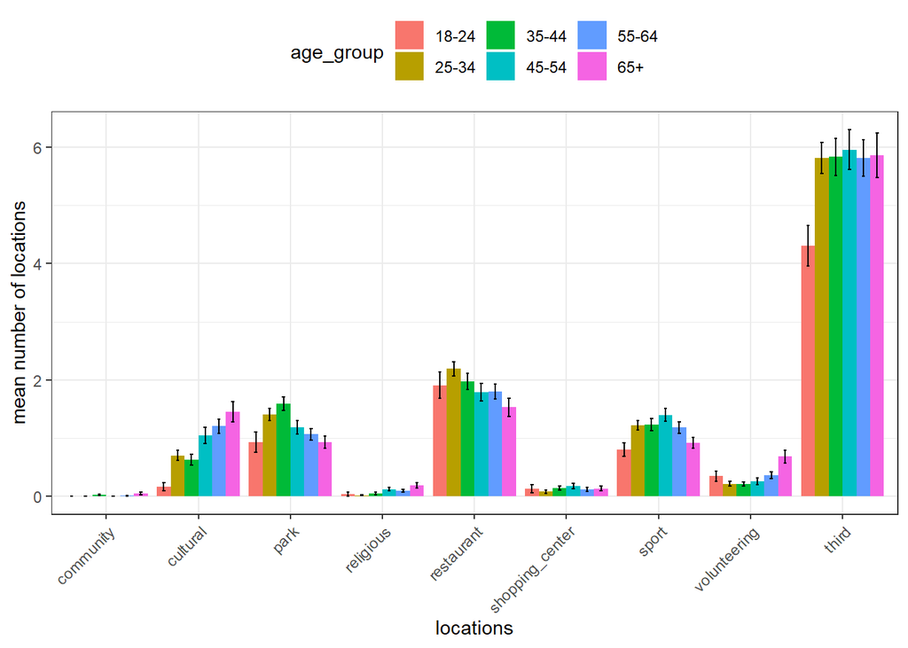

### Gender

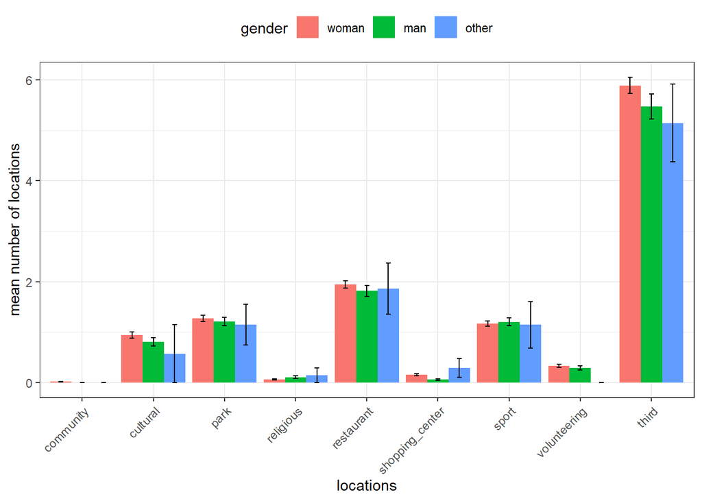

### income

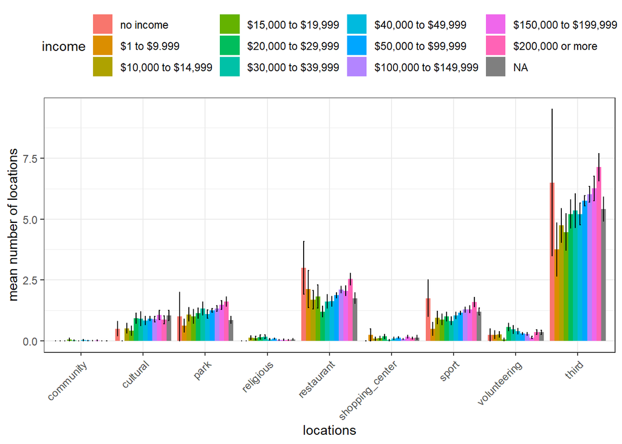

### White

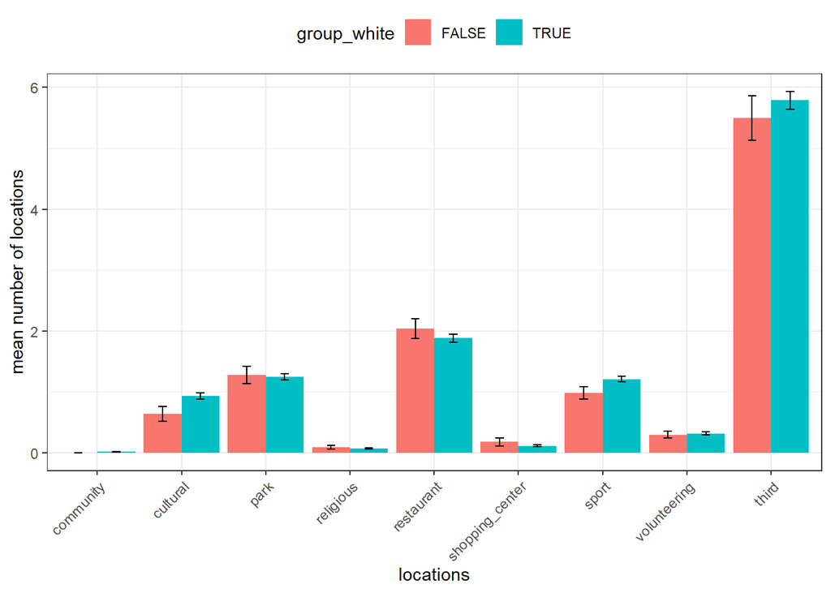

## People seen in third place by socio-demo

Average number of people seen by socio-demographic categories. Error bars represent standard errors of the means.

### Age group

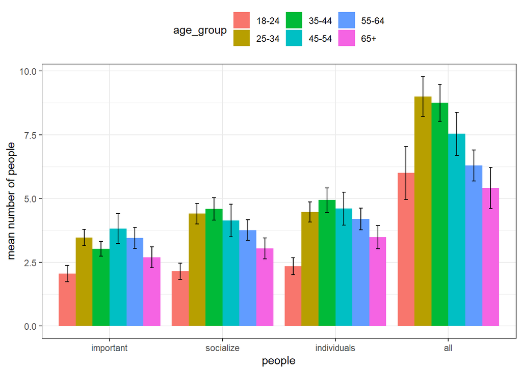

### Gender

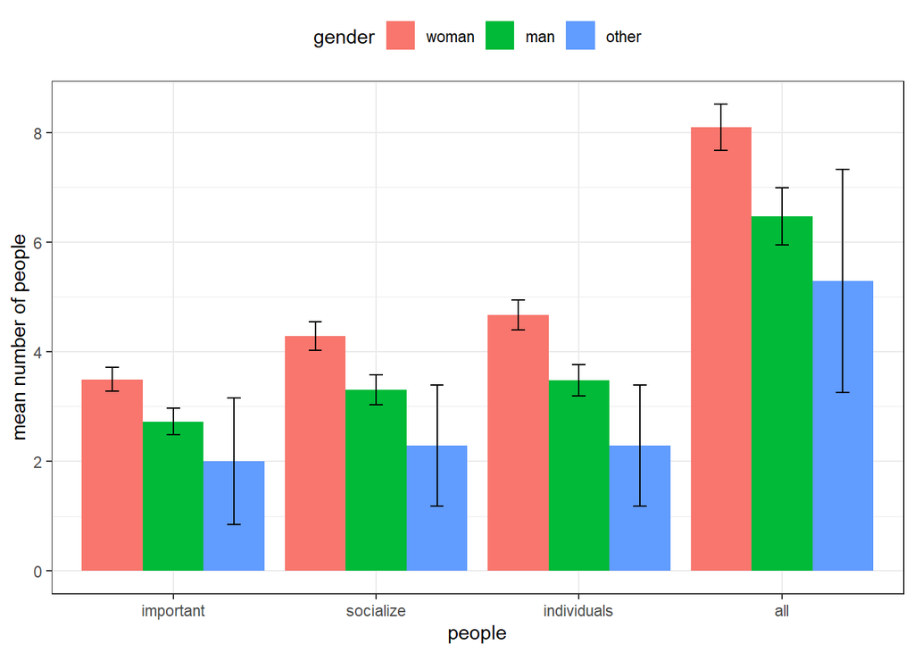

### income

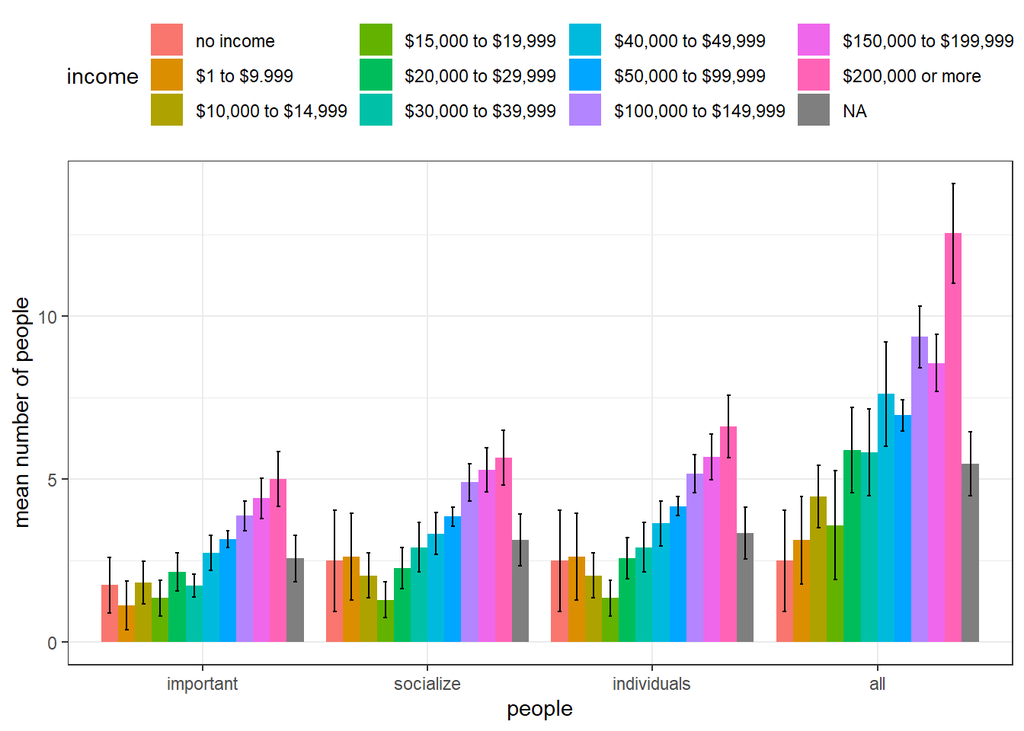

### White

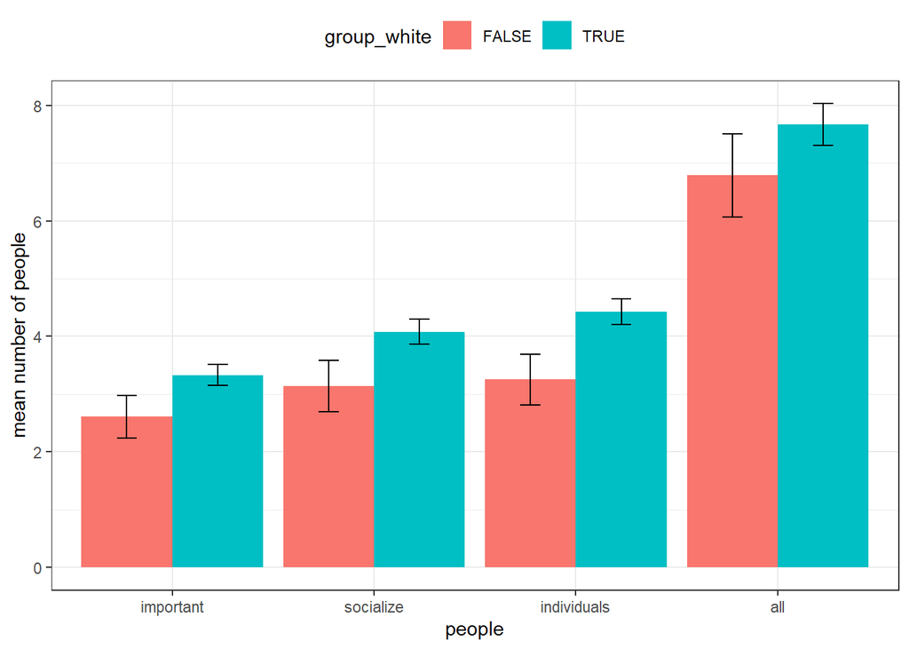

## People types by location types

Average number of people seen, stratified by types, in different third places. Error bars represent standard errors of the means.

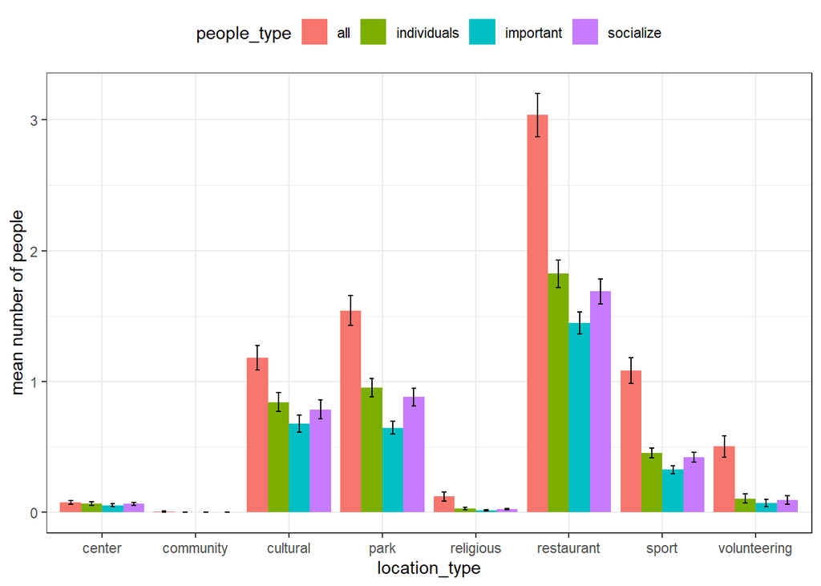

## People seen in location types by socio-demo

Average number of people seen in different third places by socio-demographic categories. Error bars represent standard errors of the means.

### Age group

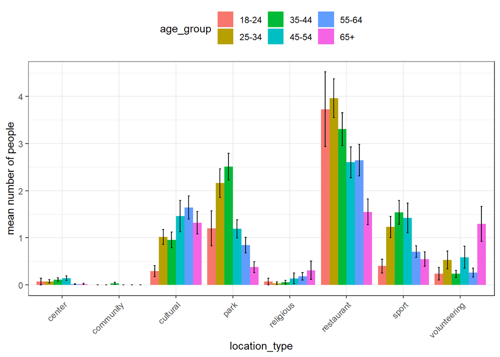

### Gender

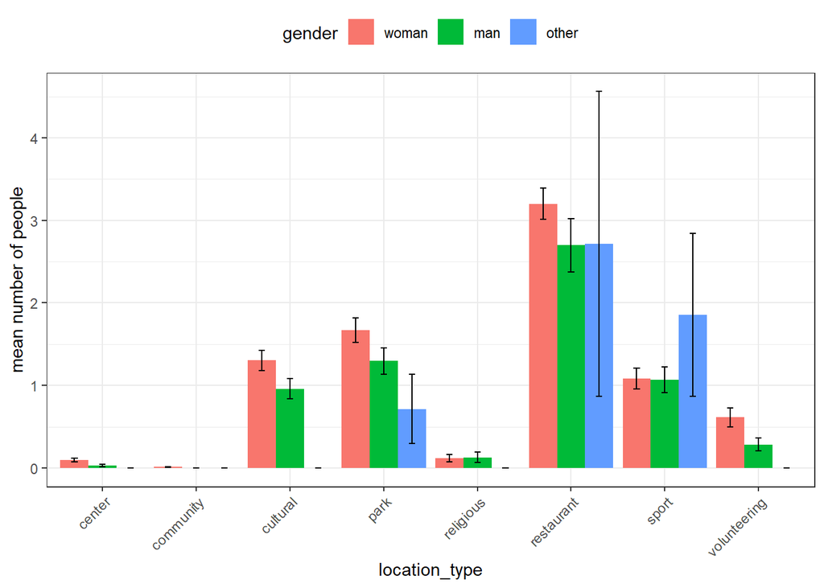

### income

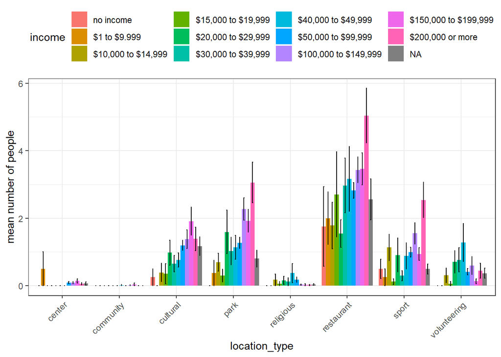

### White

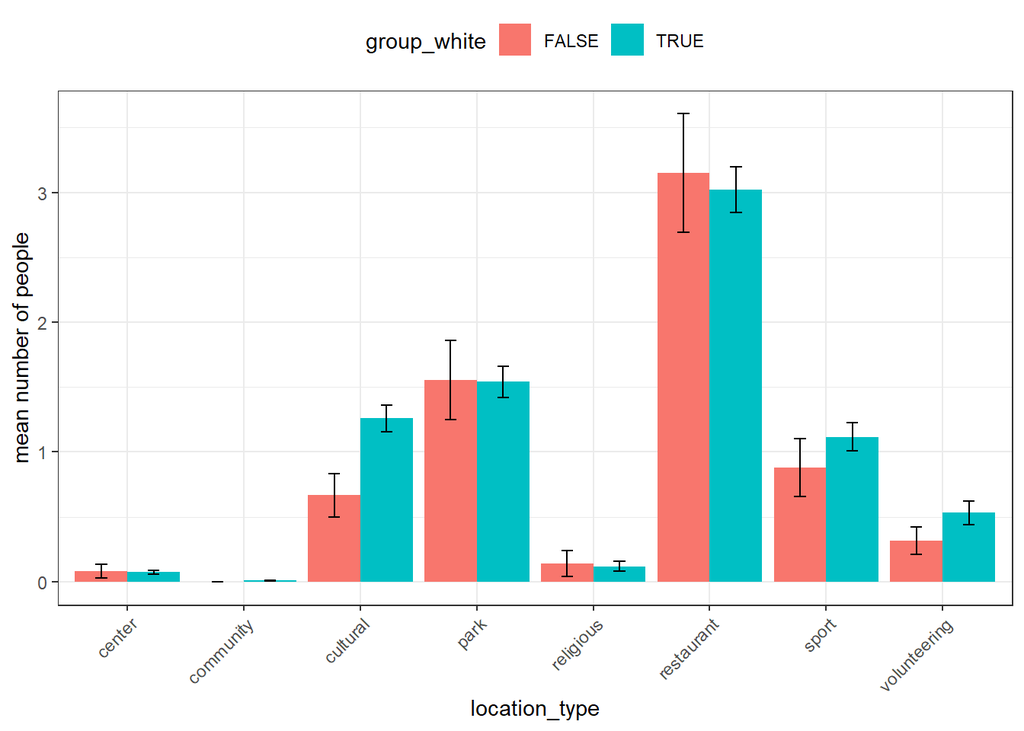

# F. Regressions

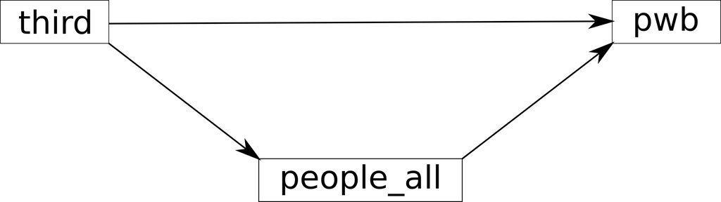

**Mediation model**

**third = number of third places; pwb = personnal well-being; people_all = number of people seen in third places**

## Separated regression results

|  | Dependant pwb | Dependant people_all | Dependant pwb |
| --- | --- | --- | --- |
| third | 0.040** | 1.579*** |  |
|  | [0.014, 0.066] | [1.445, 1.712] |  |
| people_all |  |  | 0.009 |
|  |  |  | [-0.002, 0.019] |
| Num.Obs. | 768 | 768 | 768 |
| R2 | 0.113 | 0.454 | 0.105 |
| R2 Adj. | 0.095 | 0.443 | 0.087 |
| Std. Errors | BOOTSTRAP | BOOTSTRAP | BOOTSTRAP |

<sup>a</sup> Simulation: 1000  
<sup>b</sup> Control for age_group, gender, income, white  
+ p < 0.1, * p < 0.05, ** p < 0.01, *** p < 0.001

## Separated models diagnostics

### A

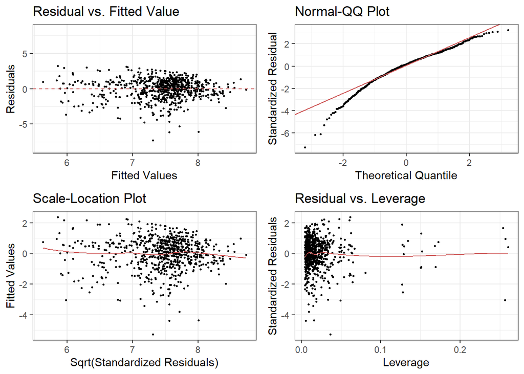

### B

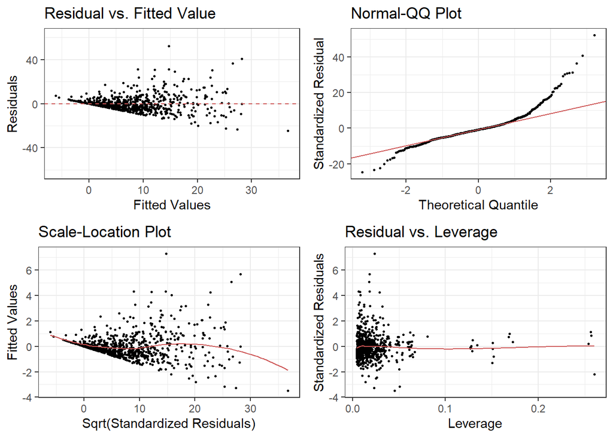

### C

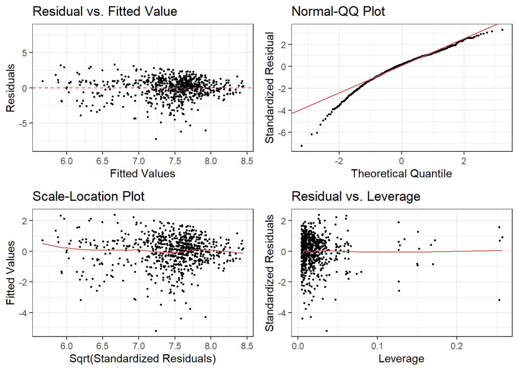

### Third and people_all histograms

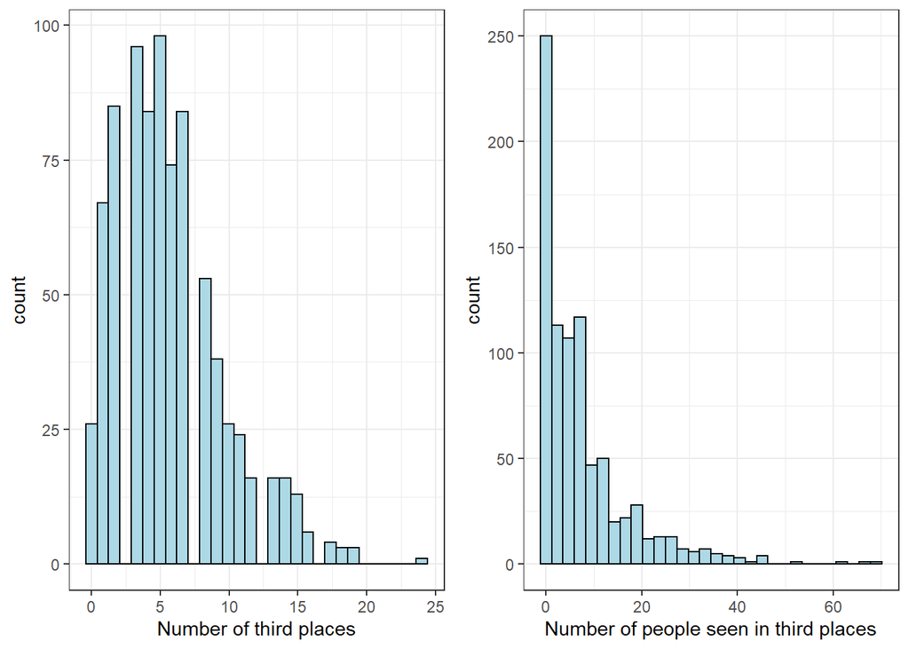

## Mediation model

```
##
## Causal Mediation Analysis
##
## Quasi-Bayesian Confidence Intervals
##
##                Estimate 95% CI Lower 95% CI Upper p-value
## ACME           -0.00476     -0.02249         0.01   0.628
## ADE             0.04496      0.01136         0.08   0.006 **
## Total Effect    0.04020      0.01568         0.07   0.002 **
## Prop. Mediated -0.11110     -0.66719         0.46   0.630
## ---
## Signif. codes:  0 '***' 0.001 '**' 0.01 '*' 0.05 '.' 0.1 ' ' 1
##
## Sample Size Used: 768
##
##
## Simulations: 1000
```

*ACME: Average Causal Mediation Effect*

*ADE: Average Direct Effect*

*Both statistics represents the **population averages** of these causal mediation and direct effects*

*Total effect: ACME + ADE*

*Prop. Mediated: The proportion of the effect of the IV on the DV that goes through the mediator*

**Reference:** Imai K, Keele L, Tingley D, Yamamoto T (2011). “Unpacking the Black Box: Learning about Causal Mechanisms from Experimental and Observational Studies.”American Political Science Review,105(4), 765–789. [URL](http://imai.princeton.edu/research/mediationP.html.)

**Quick tutorial:** see this [link](https://towardsdatascience.com/doing-and-reporting-your-first-mediation-analysis-in-r-2fe423b92171)

# G. Take Home

**Bivariate**

- Number of third places seem to increase with income
- Number of cultural/leisure and volunteering seems to increase with age
- Number of parks seems higher among 25-44 years old
- People seen in third places seems higher among 25-44 years old and among women
- People seen in third places seems to increase with income
- Restaurant, park and cultural/leisure, and sport seems to be the locations were participants see more people
- Volunteering seems also important activities to see people at 65+ years and more

**Regression**

- Direct “effect” of number of third places on well-being is **significative**
- Mediation by number of people seen is **non significative**

# H. Next step

**Problem with count - Duplicated locations**

- Different activities happening in a same location
- Using similar geographic coordinates: 1344 activites in 626 locations
- Similar location have also close coordinates

**Problem with networks without edges**

- 85 socio-spatial have no edges (nobody are seen in any locations)
- Missing information?

**What do we do with missing income information?**

- 65 participants have not reported income
- Imputation?

**Use a more appropriate regression models in the mediation analysis?**

- Quadratic term for ceiling effect?
- Model adapted for count data with multiple zero (people_all)
  - e.g. Zero-Inflated Negative Binomial Regression

**Stratify the relations between third places, people seen and well-being**

- Test with significant others (important people, like socializing)?
- Add information on close/non close relations
- Different mecanisms by age groups?
- Specific locations (cultural, park, restaurant)?

**Do we keep other gender?**

- 1% of the sample
- Remove: gain 1 DoF

**Do we use age as continuous?**

- Gain 5 DoF